# Adding files to GitHub

“GitHub offers a centralized location where all developers can push and pull (upload and download) their code.” This means that GitHub always holds the most up-to-date code and files, handling everyone’s updates appropriately.

For now, we will only need to know how to use the GUI for GitHub in order to submit homework.

In a couple weeks we will learn to work with GitHub through the terminal using git.

- To make a repository with the GitHub GUI:
  - Visit https://github.com and log in to your personal account. From the main page, create a new repository with an initialized `README.md` file. This README file is prominently displayed in the repository and explains what the repository contains.

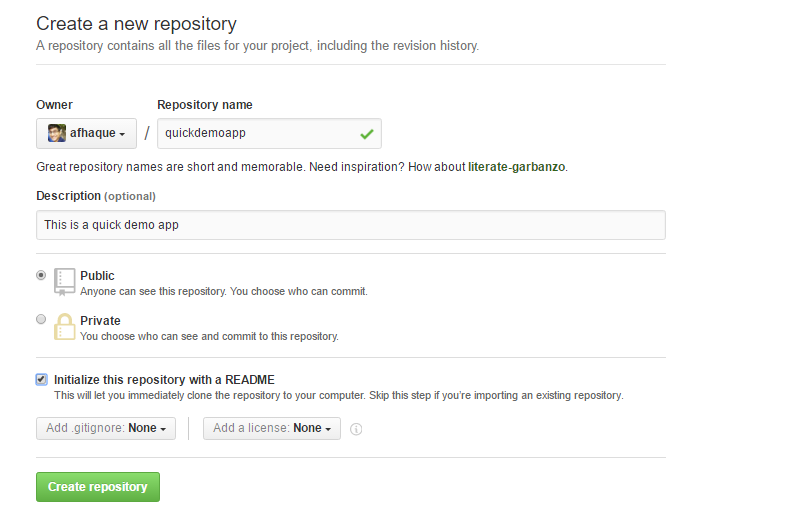

    git repo

  - Switch back to the Desktop and create a new empty Excel file and save it. This will be used to demonstrate how to upload new files. (It can be any file, but this week’s homework is Excel.)
  - Navigate back to GitHub website and click **Upload files**.

[figure not shown]

    upload file

  - Choose your Excel file in the dialog box; instead of the “Upload Files” button, you may also drag files from your desktop to the GitHub web page for a repo. Add a commit message and commit the changes. Commit messages describe what changes are made in this commit (a commit is a set of changes).
  - Finally, refresh the web page to show that the new file is now safely saved to the repository.

[figure not shown]

    drag file

- This is how you will be submitting your homework for the first two weeks. You will add all of the necessary files to their GitHub repo then submit the repository link to BCS.
- Practice using GitHub before the next class and use office hours if you run into any problems.

GitHub and similar products (e.g. GitLab) are very popular in the software development world. This class doesn’t teach you enough to not make a fool of yourself the first day on a new job!

Things to find out:

- Can you edit a file once it’s uploaded, or do you need to start over with a new repo?
- In software development, what makes a good commit?
- How can GitHub be used on collaborative projects where developers’ changes may collide?